# Predição de Votação de Deputados

José Ivan Silva da Cruz Júnior

7 de novembro de 2018

```r
library(tidyverse)
library(caret)
```

Inicialmente, precisamos fazer um limpeza nos dados e sem seguida tratá-los para podermos utilizá-los nos modelos que queremos.

```r
dadosBrutos <- read.csv("train.csv")
dadosLimpos <- dadosBrutos %>%
  mutate(comites = recursos_de_outros_candidatos.comites) %>%
  select(-sequencial_candidato, -uf, -partido, - estado_civil, -ano, -recursos_de_outros_candidatos.comites)

test <- read.csv("test.csv") %>%
  mutate(comites = recursos_de_outros_candidatos.comites)
```

Questão 1) Usando todas as variáveis disponíveis, tune (usando validação cruzada): (i) um modelo de regressão Ridge, (ii) um modelo de regressão Lasso e (iii) um modelo KNN. Para os modelos de regressão linear, o parâmetro a ser tunado é o lambda (penalização dos coeficientes) e o KNN o número de vizinhos.

Inicialmente, para o modelo Ridge , utilizo a função “train()” do pacote caret para efetuar o treino do modelo com o parâmetro “lambdas”.

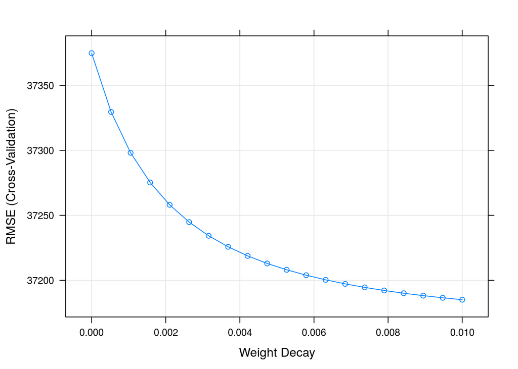

```r
lambdas <- expand.grid(lambda = seq(10^-2, 10^-9, length=20))

validacao <- trainControl(method = "cv", number = 10)

voto.modelRidge <- train(votos ~ media_despesa + total_despesa + quantidade_fornecedores + quantidade_despesas + recursos_de_partido_politico + recursos_proprios + recursos_de_pessoas_juridicas + recursos_de_pessoas_fisicas + media_receita + total_receita + quantidade_doadores + quantidade_doacoes, data = dadosLimpos, method = "ridge", tuneGrid = lambdas, preProc = c("center", "scale"), trControl = validacao)

plot(voto.modelRidge)
```

```r
voto.modelRidge
```

```
## Ridge Regression
##
## 7476 samples
##   12 predictors
##
## Pre-processing: centered (12), scaled (12)
## Resampling: Cross-Validated (10 fold)
## Summary of sample sizes: 6728, 6729, 6728, 6728, 6729, 6729, ...
## Resampling results across tuning parameters:
##
##   lambda        RMSE      Rsquared   MAE
##   0.0000000010  37374.80  0.4151208  16886.27
##   0.0005263167  37329.55  0.4156585  16884.69
##   0.0010526325  37298.12  0.4160471  16884.20
##   0.0015789482  37275.29  0.4163390  16883.86
##   0.0021052639  37258.11  0.4165649  16883.43
##   0.0026315797  37244.81  0.4167442  16882.97
##   0.0031578954  37234.29  0.4168898  16882.68
##   0.0036842112  37225.79  0.4170103  16882.44
##   0.0042105269  37218.82  0.4171117  16882.03
##   0.0047368426  37213.02  0.4171985  16881.54
##   0.0052631584  37208.13  0.4172738  16881.10
##   0.0057894741  37203.97  0.4173399  16880.50
##   0.0063157898  37200.39  0.4173987  16879.76
##   0.0068421056  37197.28  0.4174516  16878.92
##   0.0073684213  37194.57  0.4174994  16877.98
##   0.0078947371  37192.19  0.4175432  16877.49
##   0.0084210528  37190.09  0.4175835  16877.15
##   0.0089473685  37188.23  0.4176209  16876.77
##   0.0094736843  37186.58  0.4176556  16876.27
##   0.0100000000  37185.11  0.4176882  16875.66
##
## RMSE was used to select the optimal model using the smallest value.
## The final value used for the model was lambda = 0.01.
```

Para o modelo lasso, mudarei farei a mesma coisa que para o modelo Ridge, mudando apenas o método e o range do lambda.

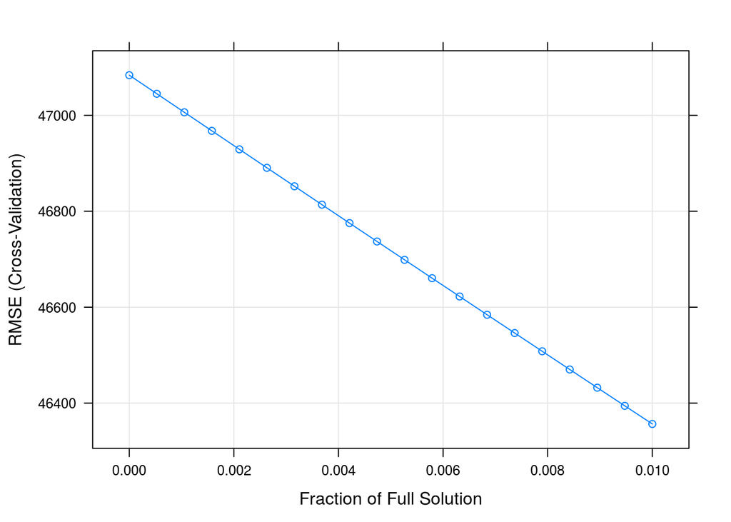

```r
lambdas <- expand.grid(fraction = seq(0.01, 10^-8, length=20))

voto.modelLasso <- train(votos ~ media_despesa + total_despesa + quantidade_fornecedores + quantidade_despesas + recursos_de_partido_politico + recursos_proprios + recursos_de_pessoas_juridicas + recursos_de_pessoas_fisicas + media_receita + total_receita + quantidade_doadores + quantidade_doacoes, data = dadosLimpos, method = "lasso", tuneGrid = lambdas, preProc = c("center", "scale"), trControl = validacao)

plot(voto.modelLasso)
```

```r
voto.modelLasso
```

```
## The lasso
##
## 7476 samples
##   12 predictors
##
## Pre-processing: centered (12), scaled (12)
## Resampling: Cross-Validated (10 fold)
## Summary of sample sizes: 6728, 6728, 6730, 6728, 6728, 6728, ...
## Resampling results across tuning parameters:
##
##   fraction      RMSE      Rsquared   MAE
##   0.0000000100  47083.79  0.4056267  28628.09
##   0.0005263253  47045.06  0.4056267  28597.09
##   0.0010526405  47006.38  0.4056267  28566.10
##   0.0015789558  46967.76  0.4056267  28535.11
##   0.0021052711  46929.18  0.4056267  28504.12
##   0.0026315863  46890.65  0.4056267  28473.13
##   0.0031579016  46852.17  0.4056267  28442.18
##   0.0036842168  46813.74  0.4056267  28411.25
##   0.0042105321  46775.36  0.4056267  28380.31
##   0.0047368474  46737.04  0.4056267  28349.39
##   0.0052631626  46698.76  0.4056267  28318.48
##   0.0057894779  46660.53  0.4056267  28287.58
##   0.0063157932  46622.36  0.4056267  28256.68
##   0.0068421084  46584.23  0.4056267  28225.82
##   0.0073684237  46546.16  0.4056267  28195.09
##   0.0078947389  46508.13  0.4056267  28164.42
##   0.0084210542  46470.16  0.4056267  28133.75
##   0.0089473695  46432.24  0.4056267  28103.08
##   0.0094736847  46394.37  0.4056267  28072.42
##   0.0100000000  46356.55  0.4056267  28041.78
##
## RMSE was used to select the optimal model using the smallest value.
## The final value used for the model was fraction = 0.01.
```

Para o modelo KNN, v será o parâmetro que indicará a quantidade de vizinhos

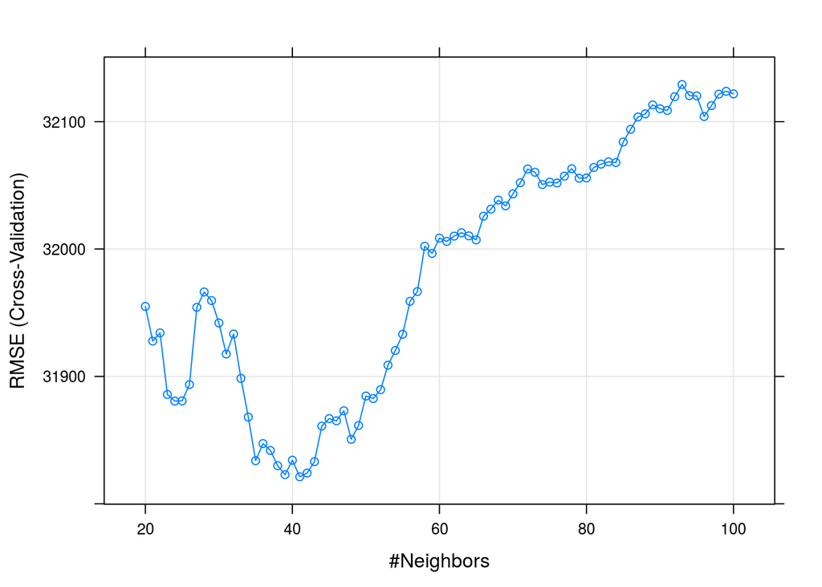

```r
v <- expand.grid(k = seq(20, 100, length=81))

voto.modelKNN <- train(votos ~ media_despesa + total_despesa + quantidade_fornecedores + quantidade_despesas + recursos_de_partido_politico + recursos_proprios + recursos_de_pessoas_juridicas + recursos_de_pessoas_fisicas + media_receita + total_receita + quantidade_doadores + quantidade_doacoes, data = dadosLimpos, method = "knn", tuneGrid = v, preProc = c("center", "scale"), trControl = validacao)

plot(voto.modelKNN)
```

```r
voto.modelKNN
```

```
## k-Nearest Neighbors
##
## 7476 samples
##   12 predictors
##
## Pre-processing: centered (12), scaled (12)
## Resampling: Cross-Validated (10 fold)
## Summary of sample sizes: 6729, 6728, 6728, 6728, 6729, 6728, ...
## Resampling results across tuning parameters:
##
##   k    RMSE      Rsquared   MAE
##    20  31954.95  0.5532855  11994.64
##    21  31927.76  0.5539429  11998.97
##    22  31934.18  0.5535787  11995.61
##    23  31885.82  0.5549657  11965.35
```

[output cut: 80 more lines]

Questão 2) Compare os três modelos em termos do erro RMSE de validação cruzada.

```r
summary(resamples(list(RIDGE= voto.modelRidge, LASSO = voto.modelLasso, KNN = voto.modelKNN)))
```

```
##
## Call:
## summary.resamples(object = resamples(list(RIDGE = voto.modelRidge, LASSO
##  = voto.modelLasso, KNN = voto.modelKNN)))
##
## Models: RIDGE, LASSO, KNN
## Number of resamples: 10
##
## MAE
##           Min.  1st Qu.   Median     Mean  3rd Qu.     Max. NA's
## RIDGE 15070.91 16417.31 16778.86 16875.66 17269.44 18728.43    0
## LASSO 25489.93 26993.72 28440.28 28041.78 28796.31 30275.00    0
## KNN   10388.10 11299.97 11739.32 11824.13 12462.64 13711.15    0
##
## RMSE
##           Min.  1st Qu.   Median     Mean  3rd Qu.     Max. NA's
## RIDGE 28023.57 29829.15 34386.77 37185.11 40035.93 67189.98    0
## LASSO 35215.24 39714.23 47394.25 46356.55 49842.69 63710.80    0
## KNN   23190.61 25934.33 28065.97 31821.23 34503.30 52544.63    0
##
## Rsquared
##            Min.   1st Qu.    Median      Mean   3rd Qu.      Max. NA's
## RIDGE 0.1262740 0.3494130 0.4358193 0.4176882 0.4991854 0.6234080    0
## LASSO 0.2546338 0.3560434 0.4180349 0.4056267 0.4707850 0.4896826    0
## KNN   0.3266019 0.4992167 0.5839067 0.5573675 0.6224054 0.7041570    0
```

Após realizar a mesma validação cruzada para os três modelos, observando o erro RMSE de cada um vemos que pelo modelo KNN obtemos o menor valor, seguido do modelo ridge e por último, o lasso.

Questão 3) Quais as variáveis mais importantes segundo o modelo de regressão Ridge e Lasso? Variáveis foram descartadas pelo Lasso? Quais?

```r
ridgeImportancia <- ggplot(varImp(voto.modelRidge))
lassoImportancia <- ggplot(varImp(voto.modelLasso))
#grid.arrange(ridgeImportancia, lassoImportancia, nrow = 1)
```

```r
pre <- predictors(voto.modelLasso)
pre
```

```
## [1] "total_despesa"
```

O restante das variáveis foram todas descartadas.

Questão 4) Re-treine o melhor modelo (usando os melhores valores de parâmetros encontrados em todos os dados, sem usar validação cruzada).

Para poder retreinar o modelo, estarei removendo as variávies que foram apontadas na questão acima. Usarei o preditor feito na útima questão.

```r
dadosRetreinados <- dadosLimpos %>% select(pre, votos)
```

Como o modelo KNN foi aquele que apresentou o menor valor de RMSE retreinaremos o mesmo.

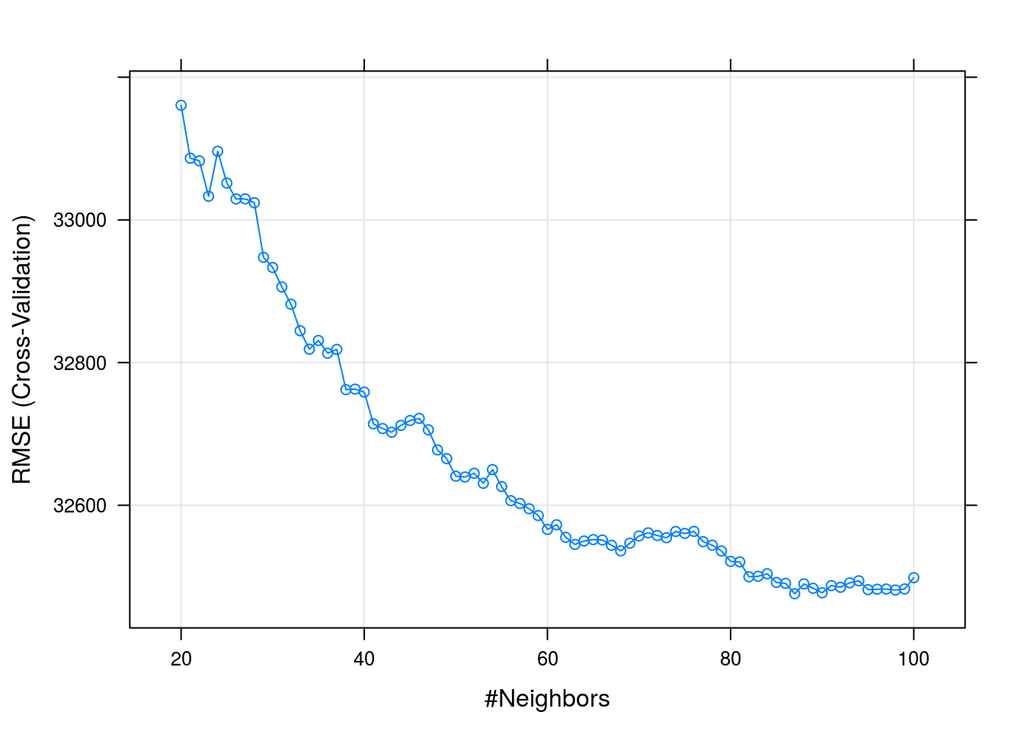

```r
voto.modelKNNRetreinado <- train(votos ~ ., data = dadosRetreinados, method = "knn",trControl = validacao,
                     preProcess = c("center","scale"), tuneGrid = v)

plot(voto.modelKNNRetreinado)
```

```r
voto.modelKNNRetreinado
```

```
## k-Nearest Neighbors
##
## 7476 samples
##    1 predictors
##
## Pre-processing: centered (1), scaled (1)
## Resampling: Cross-Validated (10 fold)
## Summary of sample sizes: 6729, 6728, 6728, 6729, 6729, 6728, ...
## Resampling results across tuning parameters:
##
##   k    RMSE      Rsquared   MAE
##    20  33160.69  0.5181140  12768.36
##    21  33086.52  0.5200607  12711.93
##    22  33082.76  0.5202307  12704.51
##    23  33033.16  0.5215315  12661.28
```

[output cut: 80 more lines]

Questão 5) Use esse último modelo treinado para prever os dados de teste disponíveis no challenge que criamos na plataforma Kaggle.

```r
prediction <- predict(voto.modelKNNRetreinado, test)
return <- data.frame(ID=test$sequencial_candidato, votos = prediction)
return$ID <- as.character(return$ID)
return
```

```
##                ID       votos
## 1     10000000135   1503.3596
## 2     10000000142   1601.9310
## 3     10000000158  64120.1839
## 4     10000000161  58260.2529
## 5     10000000163  93939.9770
## 6     10000000164   6277.1839
## 7     10000000166  67361.0115
## 8     10000000169  92166.9425
## 9     10000000170  16126.9425
## 10    10000000171  67682.7701
## 11    10000000172  44067.5057
## 12    10000000173  75228.2989
## 13    10000000176  10239.0690
## 14    10000000177  35252.4138
```

[output cut: 4584 more lines]